# Variables selection

```python
import pandas as pd
```

```python
allData=pd.read_csv('lol.csv',decimal=',')
```

```python
allDataClean=allData.drop(['Unnamed: 0','CostUnit','Date','PositionType','ValidityCard','Time','ReceiptNumber','Cashier','PaymentType','CardID','CashPoint','ItemNumber','ItemDescription'],axis=1)
```

# Unsupervised

```python
from sklearn.decomposition import PCA
from sklearn.cluster import KMeans
from collections import defaultdict
from sklearn.metrics.pairwise import euclidean_distances
from sklearn.preprocessing import StandardScaler

class PFA(object):
    def __init__(self, n_features, q=None):
        self.q = q
        self.n_features = n_features

    def fit(self, X):
        if not self.q:
            self.q = X.shape[1]

        sc = StandardScaler()
        X = sc.fit_transform(X)

        pca = PCA(n_components=self.q).fit(X)
        A_q = pca.components_.T

        kmeans = KMeans(n_clusters=self.n_features).fit(A_q)
        clusters = kmeans.predict(A_q)
        cluster_centers = kmeans.cluster_centers_

        dists = defaultdict(list)
        for i, c in enumerate(clusters):
            dist = euclidean_distances([A_q[i, :]], [cluster_centers[c, :]])[0][0]
            dists[c].append((i, dist))

        self.indices_ = [sorted(f, key=lambda x: x[1])[0][0] for f in dists.values()]
        self.features_ = X[:, self.indices_]
```

```python
import numpy as np


pfa = PFA(n_features=4)
pfa.fit(allDataClean)

# To get the transformed matrix
X = pfa.features_

# To get the column indices of the kept features
column_indices = pfa.indices_
```

```python
column_indices
```

```
[1, 4, 10, 9]
```

# Supervised

```python
import pandas as pd
import numpy as np
from sklearn.feature_selection import SelectKBest
from sklearn.feature_selection import f_regression

X = allDataClean.iloc[:,[0,1,2,3,4,5,7,8,9,10,11]]  #independent columns
y = allDataClean.iloc[:,6]    #target column i.e price range
#apply SelectKBest class to extract top 10 best features
bestfeatures = SelectKBest(score_func=f_regression, k=11)
fit = bestfeatures.fit(X,y)
dfscores = pd.DataFrame(fit.scores_)
dfcolumns = pd.DataFrame(X.columns)
#concat two dataframes for better visualization
featureScores = pd.concat([dfcolumns,dfscores],axis=1)
featureScores.columns = ['Variables','Score']  #naming the dataframe columns
print(featureScores.nlargest(10,'Score'))  #print 10 best featu
```

```
         Variables         Score
7    StandardPrice  9.372012e+08
5           Amount  7.197183e+06
4            Taxes  1.581776e+05
9           Weight  1.289061e+05
2        PriceList  5.405571e+04
1       Department  4.819324e+03
0             Firm  1.230693e+03
10    CurrencyFlag  5.984187e+02
6         NetTotal  1.101191e+02
8   KeyCardCounter  2.612406e+01
```

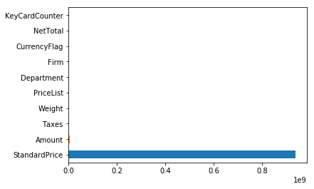

```python
#plot graph of feature importances for better visualization
feat_importances = pd.Series(bestfeatures.scores_, index=X.columns)
feat_importances.nlargest(10).plot(kind='barh')
plt.show()
```

## Conclusion

The goal of this part of the project is to know the most pertinant variables that we are going to keep and the variables that are not giving us any information and that we want to remove in order to : · Reduces Overfitting: Less redundant data means less opportunity to make decisions based on noise.

· Improves Accuracy: Less misleading data means modeling accuracy improves.

· Reduces Training Time: fewer data points reduce algorithm complexity and algorithms train faster.

To reach this goal in the best way possible we used supervised and unsupervised learning techniques and we took into consideration what we knew about our data in the business understanding step.

-->Final result: After looking at the business understanding part we had to remove the variables that are non related to our objective

- "Department"
- "PriceList"

The variables we kept are:

- "StandardPrice"
- "Amount"
- "Taxes"
- "Weight"